# Logistic Regression

## Sigmoid Function

A sigmoid function is a bounded, differentiable, real function that is defined for all real input values and has a non-negative derivative at each point and exactly one inflection point. Some of the functions listed below. This [Wikipedia page](https://en.wikipedia.org/wiki/Sigmoid_function) has good examples.

**Logistic Function** \begin{equation} f(x)=\frac{1}{1+e^{-x}} \end{equation}

**Hyperbolic Tangent** \begin{equation} f(x)=\tanh(x) \end{equation}

**Generalized Logistic Function** \begin{equation} f(x)=(1+e^{-x})^{\alpha}, \alpha > 0 \end{equation}

\begin{equation} \text{Error Function}=-\frac{1}{m}\sum_{1}^m(1-y_i)\ln(1-p_i)+y_i\ln(p_i) \end{equation}

Where we divide by m for convenience while taking derivatives and where m is the number of rows in training example.

## Gradient of the Error Function.

Since we use the sigmoid function for calculating the probabilties, therefore, $p_i=\text{sigmoid}(Wx^{(i)}+b)$ wher $x^{(i)}$ is the i^th row in dataset and W is the corressponding weights/coefficients in the linear equation.

To optimize error we will require gradient of the error function. Which is straightforward application of derivatives.

The error function dependent on the weights and bias. That is it is a scalar valued function from $\mathbb{R}^{n+1}$ to $\mathbb{R}$. \begin{equation} E(W, b)=-\frac{1}{m}\sum_{1}^m(1-y_i)\ln(1-p_i)+y_i\ln(p_i) \end{equation} Where $W=(w_1, w_2, \cdots, w_n)$.

Note that $$\frac{\partial p_i}{\partial w_j}=\frac{\partial (\text{sigmoid}(Wx^{(i)}+b))}{\partial w_j}=(p_i)(1-p_i)\cdot x_j$$

To evaluate gradient of E we will differentiante the term $(1-y_i)\ln(1-p_i)+y_i\ln(p_i)$, call it $E_i$, with repect of $w_j$. \begin{align} \frac{\partial E_i}{\partial w_j}&=\frac{\partial E_i}{\partial w_j}(1-y_i)\ln(1-p_i)+y_i\ln(p_i)\\ &=-(1-y_i)p_i\cdot x_j+y_i(1-p_i)\cdot x_j\\ &= (y_i-p_i)x_j \end{align}

Note: $x_j$ is the entry from the i^th row and j^th column.

Finally, \begin{equation} \nabla E=-\sum_{i}^m(y_i-p_i)\cdot x_j \end{equation}

We use this for gradient descent algorithm (which is also used in quadratic minimzation problem).

The above gradient can be written in matrix form \begin{equation} \nabla E=-(Y-P)\cdot X \end{equation}

Let W denote the initialised weights.

**Algorithm**

`W = W - learnrate*(grad(E))`

```python
import numpy as np
import pandas as pd
import matplotlib.pyplot as plt
import seaborn as sns
```

# Functions for regression.

Let us define the functions for the regression. We will require sigmoid function, a probabiltity function, error function, and finally a function which updates weights. We also add two functions for plotting the error and boundary lines.

```python
#Logistic  Function. Note add a column of 1's for bias.

def logistic_function(t):
  return 1/(1+np.exp(-t))

def predictor(W, X):
  """
  X: X is a m*(n+1) matrix where an extra column of 1's is added
  for bias calculation.
  W: W is (n+1)*1 size vector.
  X \dot W results in m*1 matrix of probabilities
  """
  return logistic_function(np.dot(X, W.T))

def error_value(Y, P):
  return sum(-Y*np.log(P)-(1-Y)*np.log(1-P))

def update_weights(W, P, X, Y, learnrate):
  W =W + learnrate*(np.dot((Y-P), X))
  return W
```

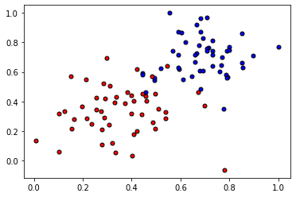

```python
data = pd.read_csv('/content/data.csv',header=None)
X = data[[0, 1]]
Y = data[2]

def plot_points(X, y):
    admitted = X[np.argwhere(y==1)]
    rejected = X[np.argwhere(y==0)]
    plt.scatter([s[0][0] for s in rejected], [s[0][1] for s in rejected], s = 25, color = 'blue', edgecolor = 'k')
    plt.scatter([s[0][0] for s in admitted], [s[0][1] for s in admitted], s = 25, color = 'red', edgecolor = 'k')

def display(m, b, color='g--'):
    plt.xlim(-0.05,1.05)
    plt.ylim(-0.05,1.05)
    x = np.arange(-10, 10, 0.01)
    plt.plot(x, m*x+b, color)
X_arr = np.array(X)
Y_arr = np.array(Y)
plot_points(X_arr,Y_arr)
plt.show()
```

# Training the dataset

The below function trains the dataset and plots the error and boundary line for the two dimensional data.

```python
np.random.seed(20)

epochs = 100
learnrate = 0.01

def train(features, targets, epochs, learnrate, graph_lines=False):
    errors = []
    n_records, n_features = features.shape
    last_loss = None
    weights = np.random.normal(scale=1 / n_features**.5, size=n_features-1)
    bias = 0.01
    weights = np.append(weights, bias)
    for e in range(epochs):
      output = predictor(weights, features)
      error = error_value(targets, output)
      weights = update_weights(weights,output, features, targets, learnrate)

    # Printing out the log-loss error on the training set
      out = predictor(weights, features)
      loss = np.mean(error_value(targets, out))
      errors.append(loss)
      if e % (epochs / 10) == 0:
          print("\n========== Epoch", e,"==========")
          if last_loss and last_loss < loss:
              print("Train loss: ", loss, "  WARNING - Loss Increasing")
          else:
              print("Train loss: ", loss)
          last_loss = loss
          predictions = out > 0.5
          accuracy = np.mean(predictions == targets)
          print("Accuracy: ", accuracy)
      if graph_lines and e % (epochs / 100) == 0:
          display(-weights[0]/weights[1], -weights[2]/weights[1])

    # Plotting the solution boundary
    plt.title("Solution boundary")
    display(-weights[0]/weights[1], -weights[2]/weights[1], 'black')

    # Plotting the data
    plot_points(features[:,:features.shape[1]-1], targets)
    plt.show()

    # Plotting the error
    plt.title("Error Plot")
    plt.xlabel('Number of epochs')
    plt.ylabel('Error')
    plt.plot(errors)
    plt.show()
    return weights
```

[output not shown]

```python
#Adding a column of ones so we don't have to keep track of the bias term separately.

X= np.hstack([X, np.ones([X.shape[0], 1], dtype=np.int32)])
print(X.shape)
Y=np.array(Y)
```

```
(100, 3)
```

# Final Stage

```
========== Epoch 0 ==========
Train loss:  72.44996738068772
Accuracy:  0.41

========== Epoch 10 ==========
Train loss:  62.10529758964154
Accuracy:  0.69

========== Epoch 20 ==========
Train loss:  55.347563587359105
Accuracy:  0.84

========== Epoch 30 ==========
Train loss:  50.06982571680566
Accuracy:  0.93

========== Epoch 40 ==========
Train loss:  45.88573209887136
Accuracy:  0.93

========== Epoch 50 ==========
Train loss:  42.513139935478776
Accuracy:  0.93

========== Epoch 60 ==========
Train loss:  39.749867550759014
Accuracy:  0.93

========== Epoch 70 ==========
Train loss:  37.45112267205692
Accuracy:  0.93

========== Epoch 80 ==========
Train loss:  35.51228345688485
Accuracy:  0.93

========== Epoch 90 ==========
Train loss:  33.85673438436189
Accuracy:  0.93
```

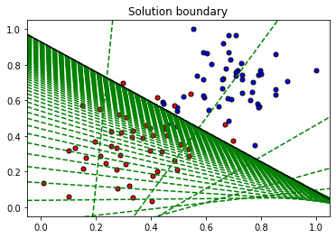

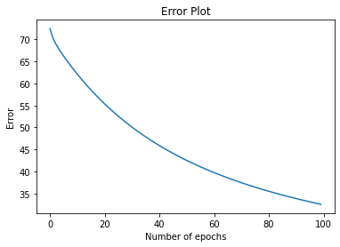

```python
w = train(X, Y, epochs, learnrate, True)
```